# My Simple Logistic Regression

#### Background

This data was taken from the US Census Bureau data of Washington residents from 2012-2016. This is a rich dataset with many parameters, but I just wanted to focus on age and if the individual was married or not. The dataset can be found here: https://factfinder.census.gov/faces/tableservices/jsf/pages/productview.xhtml?pid=ACS_pums_csv_2012_2016&prodType=document and is titled “Washington Population Records”. I wanted to use the US records file, but since it was 2.3 GB it was going to take an hour to download, and therefore I chose to go with the Washington data subset, which still had over 350,000 rows of information. The married column (denoted as “MAR”), has 5 values, with the following meanings: 1 .Married 2 .Widowed 3 .Divorced 4 .Separated 5 .Never married or under 15 years old

By using the 5th number of “never married” as successful, or y = 1, and the other numbers as “failures”" (being married), I can perform a logistic regression on the data.

#### Question and Hypothesis

I wanted to figure out if I could predict the likelihood of a person being married based on their age. Therefore, my question is, “Can I fit a logistic model to predict the likelihood someone is married by using their age?”

The hypothesis is as follows:

$$H_0: \beta_1 = 0 \\
H_a: \beta_1 \neq 0$$

#### Logistic Model

The following model is used to help predict the likelihood of having married once at various ages:
$$P(Y_i = 1|x_i) = \frac{e^{\beta_0+\beta_1 x_i}}{1+e^{\beta_0 + \beta_1 x_i}} = \pi_i$$
where for observation $i$:

- $Y_i = 1$ is interpreted as not getting married,
- $Y_i=0$ is interpreted as getting married at least once, and
- $x_i$ is interpreted as the person’s age.

#### Fitting the Model

|  | Estimate | Std. Error | z value | Pr(>\|z\|) |
| --- | --- | --- | --- | --- |
| **(Intercept)** | 3.982 | 0.01421 | 280.2 | 0 |
| **Age** | -0.122 | 0.000391 | -312.1 | 0 |

(Dispersion parameter for binomial family taken to be 1 )

| Null deviance: | 475924 on 353680 degrees of freedom |
| --- | --- |
| Residual deviance: | 227463 on 353679 degrees of freedom |

Tthe $p$-value for the test of `Age` shows a significant result $(p = <2e-16)$ giving sufficient evidence to conclude that $\beta_1 \neq 0$, this means that age does affect the likelihood of being married or not.

#### Visualizing the Model

The following is a plot of the data presented above.

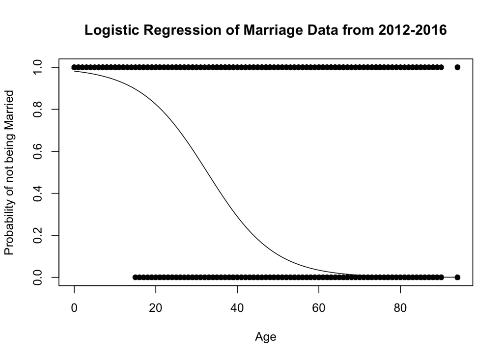

This plot further illustrates the point that this data is a good dataset to perform the logistic regression on because there is a steep curve in the line, going all the way from 1 to 0 and forming a nice s-curve.

#### Validating the data

I still need to do some diagnosis and check to see if this data really is appropriate for a logistic regression. Since there are many duplicate x-values, I will use the pchisq() function to check for goodness of fit below.

```r
pander(pchisq(227463, 353679, lower.tail = FALSE))
```

*1*

The data shows that this model is a good fit for the data and the logistic regression is appropriate.

#### Prediction

I want to put the model to the test and see what the probability is that a 25 year old is not married.

| 1 |
| --- |
| 0.7173 |

The result is the there is a 71.73% chance that I am not married if I am a Washington resident. Also below, I did a quick calculation to see how quickly the chance of being not married decreases with age.

Using the following equation, I can find how much the chances of not being married decreases with age: $e^{b_1} = e^{-0.122036} \approx 0.89$. This is computed below.

```r
pander(exp(-0.122036))
```

*0.8851*

This shows that for every year increase in age, the chance of not being married decreases by a factor of .8851.

#### Conclusion

Overall, I liked how this logistical regression turned out. I think that it was interesting to see the probability of not being married at different ages and finding that age is definitely a factor in determining the likelihood of not being married once during a persons life.